# Predicting Activity Quality from Accelerometer Data

## Model Results

Let’s inspect some aspects of the resulting model:

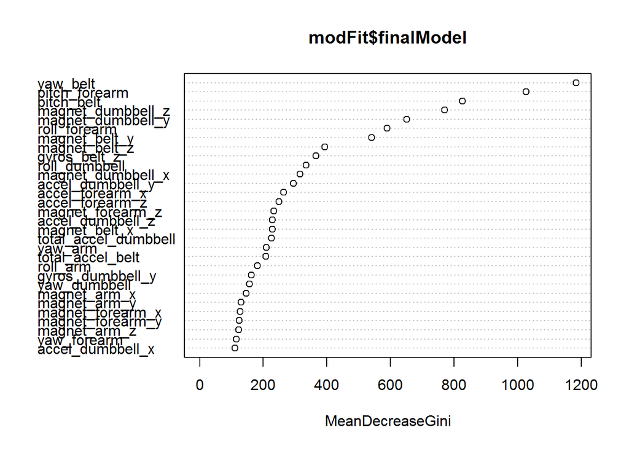

```r
varImpPlot(modFit$finalModel)
```

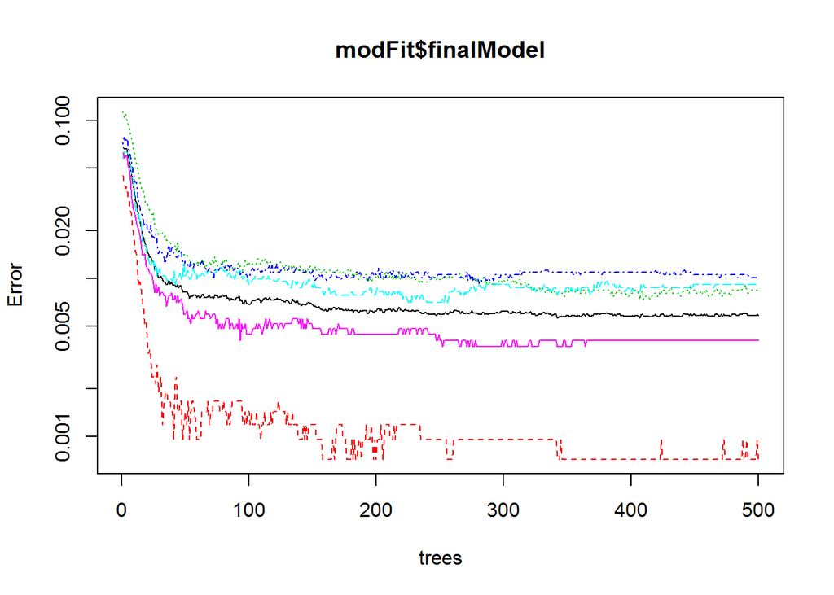

```r
plot(modFit$finalModel, log="y")
```

# Model Performance (Error Estimation)

Because we used Random Forest, we can inspect the estimate of error computed during model generation:

```r
modFit$finalModel
```

```
##
## Call:
##  randomForest(x = x, y = y, mtry = param$mtry)
##                Type of random forest: classification
##                      Number of trees: 500
## No. of variables tried at each split: 23
##
##         OOB estimate of  error rate: 0.58%
## Confusion matrix:
##      A    B    C    D    E  class.error
## A 4182    2    0    0    1 0.0007168459
## B   19 2824    5    0    0 0.0084269663
## C    0   15 2541   11    0 0.0101285547
## D    0    0   18 2390    4 0.0091210614
## E    0    0    4    7 2695 0.0040650407
```

This shows very low errors during cross validation.

In addition, we can apply the model to make predictions on the previously reserved test set and compare those predictions to the true labeling for an out-of-sample error:

```r
predictions <- predict(modFit, newdata=testing)
cm <- confusionMatrix(predictions, testing$classe)
cm
```

```
## Confusion Matrix and Statistics
##
##           Reference
## Prediction    A    B    C    D    E
##          A 1394    7    0    0    0
##          B    1  940    3    0    0
##          C    0    2  850    7    1
##          D    0    0    2  797    1
##          E    0    0    0    0  899
##
## Overall Statistics
##
##                Accuracy : 0.9951
##                  95% CI : (0.9927, 0.9969)
##     No Information Rate : 0.2845
##     P-Value [Acc > NIR] : < 2.2e-16
##
##                   Kappa : 0.9938
##  Mcnemar's Test P-Value : NA
##
## Statistics by Class:
##
##                      Class: A Class: B Class: C Class: D Class: E
## Sensitivity            0.9993   0.9905   0.9942   0.9913   0.9978
## Specificity            0.9980   0.9990   0.9975   0.9993   1.0000
## Pos Pred Value         0.9950   0.9958   0.9884   0.9963   1.0000
## Neg Pred Value         0.9997   0.9977   0.9988   0.9983   0.9995
## Prevalence             0.2845   0.1935   0.1743   0.1639   0.1837
## Detection Rate         0.2843   0.1917   0.1733   0.1625   0.1833
## Detection Prevalence   0.2857   0.1925   0.1754   0.1631   0.1833
## Balanced Accuracy      0.9986   0.9948   0.9958   0.9953   0.9989
```

This shows an overall accuracy of 0.995106 with a p value effectivly equal to 0.

# Employ Model

```r
answers <- predict(modFit, newdata=verification)
```

The instructions for the assignment provide the following function for generating the submission files from the predicted answers:

```r
pml_write_files = function(x){
    n = length(x)
    for(i in 1:n){
        filename = paste0("problem_id_",i,".txt")
        write.table(x[i],file=filename,quote=FALSE,row.names=FALSE,col.names=FALSE)
    }
}
```

And finally we generate our answer files with the following call:

```r
pml_write_files(answers)
```